# White Shark Movement Analysis Report

Pramir_KC

2022-07-24

# Background and Research Question

The main question that I have from this dataset is what kind of movement of animal and dive should we consider as foraging behaviour and at what time of the day those foraging behaviour appear? There is clear water at Guadalupe Island (GI) and it is believed that the hunting happens in deeper water where the light level is low (Papastamatiou et al., 2021). From this information an interesting question arises: - Can we observe some periodic foraging behaviour at certain hours of the day? By analysing this data, we can make an inference if there is a specific hunting time for this shark or is it random.

Loading all data for shark movement in NetCDF4 format. The .csv file for the data was converted to NetCdf4 format using ’xarray.Dataset.to_netcdf’code in python.

```r
setwd("/misc/scratch/pramirk")
library(tagtools)
MN <- load_nc('sharkmov_fin.nc')
```

##Adding the metadata so that the variables are compatible with tagtools. Adding metadata for Depth

```r
MN$Depth$sampling_rate <- 20
MN$Depth$sampling <- 'regular'
MN$Depth$sampling_rate_unit <- 'HZ'
MN$Depth$start_offset <- 0
MN$Depth$creation_date <- "08.10.2017 17:16.0"
MN$Depth$start_offset_units <- 'second'
MN$Depth$axis <- 'FRU'
```

Adding metadata for Depth1

```r
MN$Depth1$sampling_rate <- 20
MN$Depth1$sampling <- 'regular'
MN$Depth1$sampling_rate_unit <- 'HZ'
MN$Depth1$start_offset <- 0
MN$Depth1$creation_date <- "08.10.2017 17:16.0"
MN$Depth1$start_offset_units <- 'second'
MN$Depth1$axis <- 'FRU'
```

Adding metadata for temperature

```r
MN$Temperature$sampling_rate <- 20
MN$Temperature$sampling <- 'regular'
MN$Temperature$sampling_rate_unit <- 'HZ'
MN$Temperature$start_offset <- 0
MN$Temperature$creation_date <- "08.10.2017 17:16.0"
MN$Temperature$start_offset_units <- 'second'
MN$Temperature$axis <- 'FRU'
```

Adding metadata to accelerometer, gyroscope and magnatometer and combing all three axis into one data matrax for each of the accelerometer, gyroscope and magnatometer data.

```r
# Adding the metadata to the accelerometer data
MN$AccX$sampling_rate <- 20
MN$AccX$sampling <- "regular"
MN$AccX$sampling_rate_unit<- 'Hz'
MN$AccX$start_offset <- 0
MN$AccX$creation_date <- "08.10.2017 17:16.0"
MN$AccX$start_offset_units <- 'second'
MN$AccX$unit_label <- "m/s^2"
A <- cbind(MN$AccX$data,MN$AccY$data,MN$AccZ$data)
MN$AccX$data <- A


# Adding the metadata to the magnetometer
MN$MagX$sampling_rate <- 20
MN$MagX$sampling <- "regular"
MN$MagX$sampling_rate_unit<- 'Hz'
MN$MagX$start_offset <- 0
MN$MagX$creation_date <- "08.10.2017 17:16.0"
MN$MagX$start_offset_units <- 'second'
MN$MagX$unit_label <- "\\muT"
MN$MagX$unit <- "uT"
M <- cbind(MN$MagX$data,MN$MagY$data,MN$MagZ$data)
MN$MagX$data <- M


# Ading the metadata for gyroscope
MN$GyrX$sampling_rate <- 20
MN$GyrX$sampling <- "regular"
MN$GyrX$sampling_rate_unit<- 'Hz'
MN$GyrX$start_offset <- 0
MN$GyrX$creation_date <- "08.10.2017 17:16.0"
MN$GyrX$start_offset_units <- 'second'
MN$GyrX$unit_label <- "\\muT"
MN$GyrX$unit <- "uT"
G <- cbind(MN$GyrX$data,MN$GyrY$data,MN$GyrZ$data)
MN$GyrX$data <- G
```

#### Plotting the Depth, Acceleremeter, Gyroscope and Magnetometer values

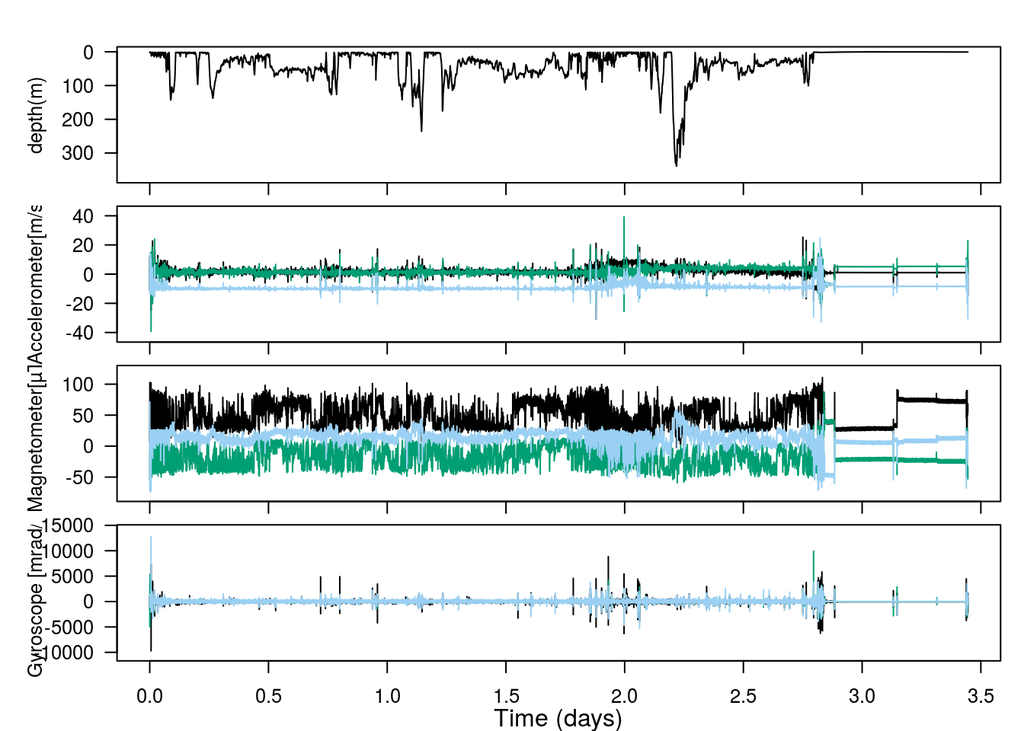

```r
plott(list(MN$Depth,MN$AccX,MN$MagX,MN$GyrX), r=c(1,0,0,0),panel_labels = c('depth(m)','Accelerometer[m/s²])','Magnetometer[µT]','Gyroscope [mrad/s]'))
```

### From the above figure, it appears that the datapoints after 2.7 days are irrelevant for analysis( I am not sure what happened to the sensors over there). Therefore, I am cropping the data and including the data until 2.7 days.

```r
# cropping the data until 2.7 days

P = crop_to(MN$Depth, tcues = c(0, 2.7*60*60*24))
P1 = crop_to(MN$Depth1, tcues = c(0, 2.7*60*60*24))
T = crop_to(MN$Temperature, tcues = c(0, 2.7*60*60*24))
A = crop_to(MN$AccX, tcues = c(0, 2.7*60*60*24))
M = crop_to(MN$MagX, tcues = c(0, 2.7*60*60*24))
G = crop_to(MN$GyrX, tcues = c(0, 2.7*60*60*24))
MN$`Date (UTC)`$sampling_rate = 20
MN$`Time (UTC)`$sampling_rate =20
Dt = crop_to(MN$`Date (UTC)`, tcues = c(0, 2.7*60*60*24))
Tm =crop_to(MN$`Time (UTC)`, tcues = c(0, 2.7*60*60*24))
```

# Plotting Depth Accelerometer , Magnatometer and Gyroscope values for cropped data

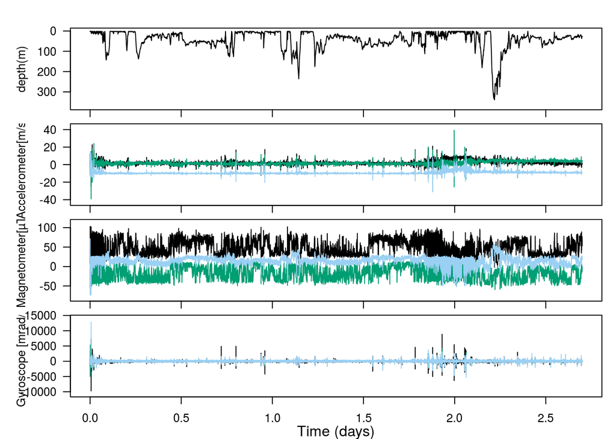

```r
plott(list(P$data,A,M,G),fsx=c(20,20,20,20),r=c(1,0,0,0),panel_labels = c('depth(m)','Accelerometer[m/s²])','Magnetometer[µT]','Gyroscope [mrad/s]'))
```

# Plotting Depth, Depth1 and Temperature for cropped data.

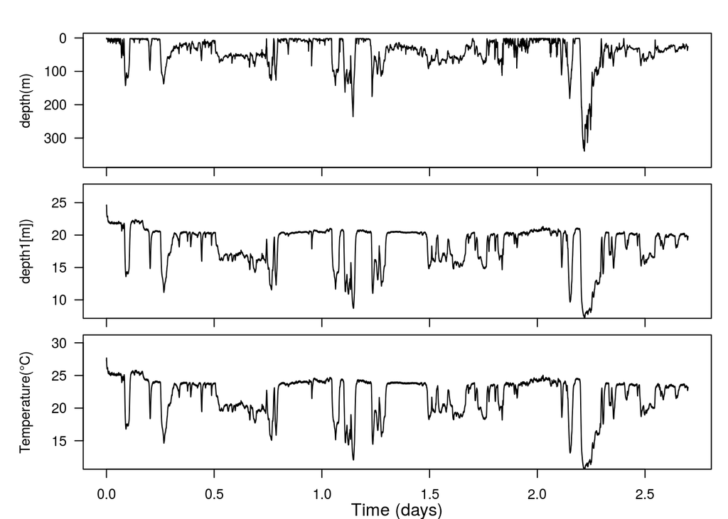

```r
plott(list(P$data,P1$data, T$data),fsx=c(20,20,20),r=c(1,0,0),panel_labels = c('depth(m)','depth1[m])','Temperature(\u00B0C)'))
```

**From the above figure there there are dives at specific time of the day and the dives patten corresponds nicely with the decrease in temperature. One of my goals is to understand at what part of the day are the dives happening.**.

# From the accelerometer data, pitch and roll can be calculated. Pitch and roll represents the changes in body orientation.

Rotation around the front-to-back axis is called roll. Rotation around the side-to-side axis is called pitch. Rotation around the vertical axis is called yaw. (National air and space musium, 2022) # Heading Papastamatiou et al. (2021) also discusses about the heading s.d. which is the measure of tortuosity (movement) or straight movement. Usually Heading -ARS (area restrictive searching) with tortious movement is observed while hunting

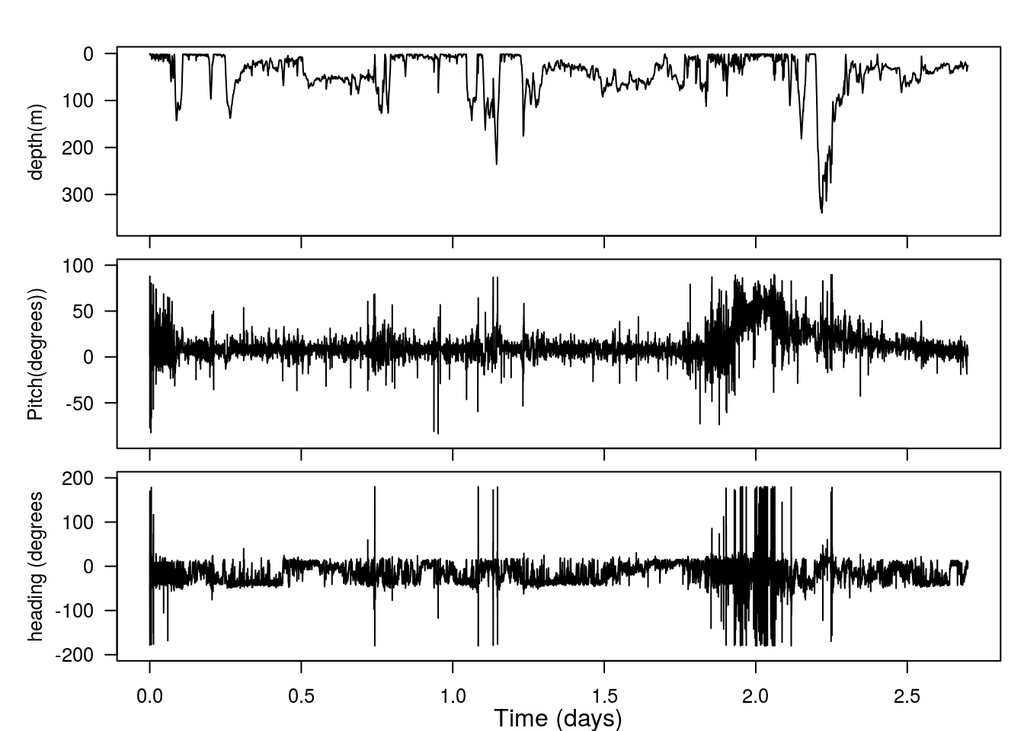

```r
p <- a2pr(A=A$data)
h <- m2h(M=M$data,A=A$data)
#par(mfrow=c(3,1),mar=c(0,4,1,1))
#plot(P$data,pch=".",ylab="Depth (m)",xaxt="n")
#index of animal at the prolonged surfacing half way through
#plot(p$p*180/pi,pch=".",ylab="Pitch (degrees)",xaxt="n")
#par(mar=c(4,4,1,1))
#plot(h$h*180/pi,pch=".",xlab="Time",ylab="Heading (degrees)")
#abline(v=c(9000,11700),lty=2,col="green")
plott(list(P$data,p$p*180/pi, h$h*180/pi),fsx=c(20,20,20),r=c(1,0,0),panel_labels = c('depth(m)','Pitch(degrees))','heading (degrees'))
```

### cropping the data to find steady swimming. The steady swimming values will help determine the stroking rate.

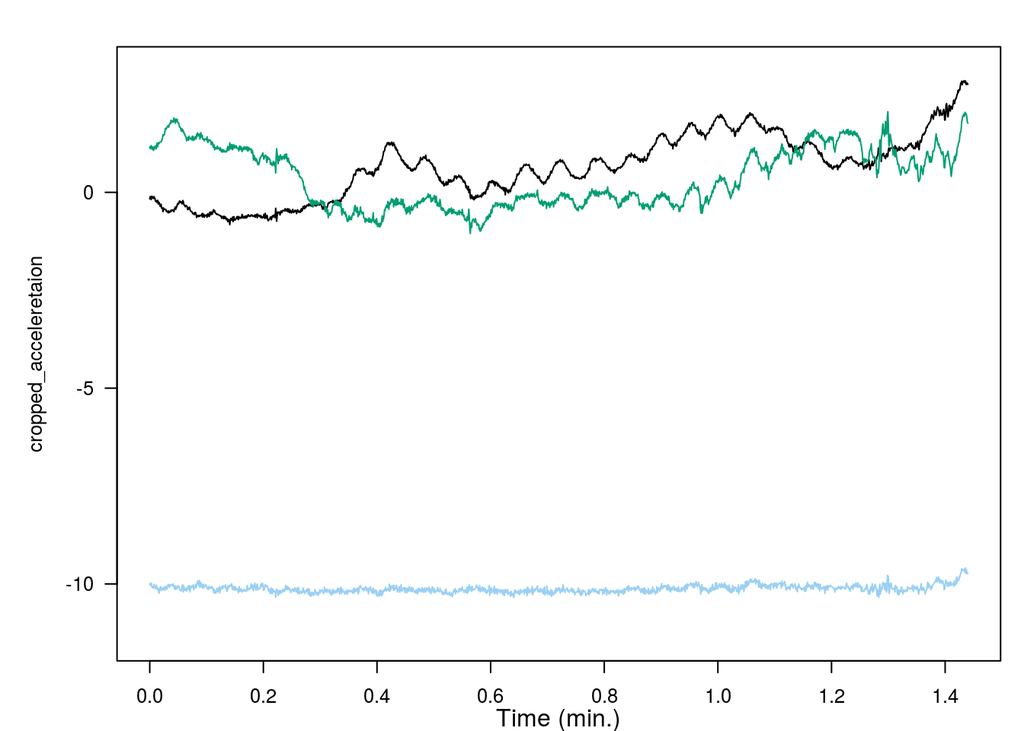

```r
Mc <- crop_to(M, tcues = c(1.35*60*24, 1.41*60*24))
Ac <- crop_to(A, tcues = c(1.35*60*24, 1.41*60*24))
Gc <- crop_to(G, tcues = c(1.35*60*24, 1.41*60*24))
plott(list(cropped_acceleretaion= Ac))
```

### Determining the stroking rate from the steady accelerometer value, Ac.

```r
str <- dsf(Ac)
str
```

```
## $fpk
## [1] 0.2985204
##
## $q
## [1] 32.70179
```

### A good starting choice for the filter cut-off frequency is 70 percent of the stroking rate.

Complimentary filterning of a signal breaks two or more frequencies such that the sum of signals equal to original signal. In our case comp_filt function breaks down the accelerometer and magnatometer values into high frequencies and low frequency values.

```r
fc <- 0.30*0.7
Af <- comp_filt(A,fc=fc)
Mf <- comp_filt(M,fc=fc)
```

Here, Ahigh is the high pass filtered acceleration and Alow is low pass filtered acceleration.

```r
Alow <- Af[[1]]
Ahigh <- Af[[2]]
Mlow <- Mf[[1]]
Mhigh <- Mf[[2]]
```

#plotting Ahigh, Mhigh and two depths

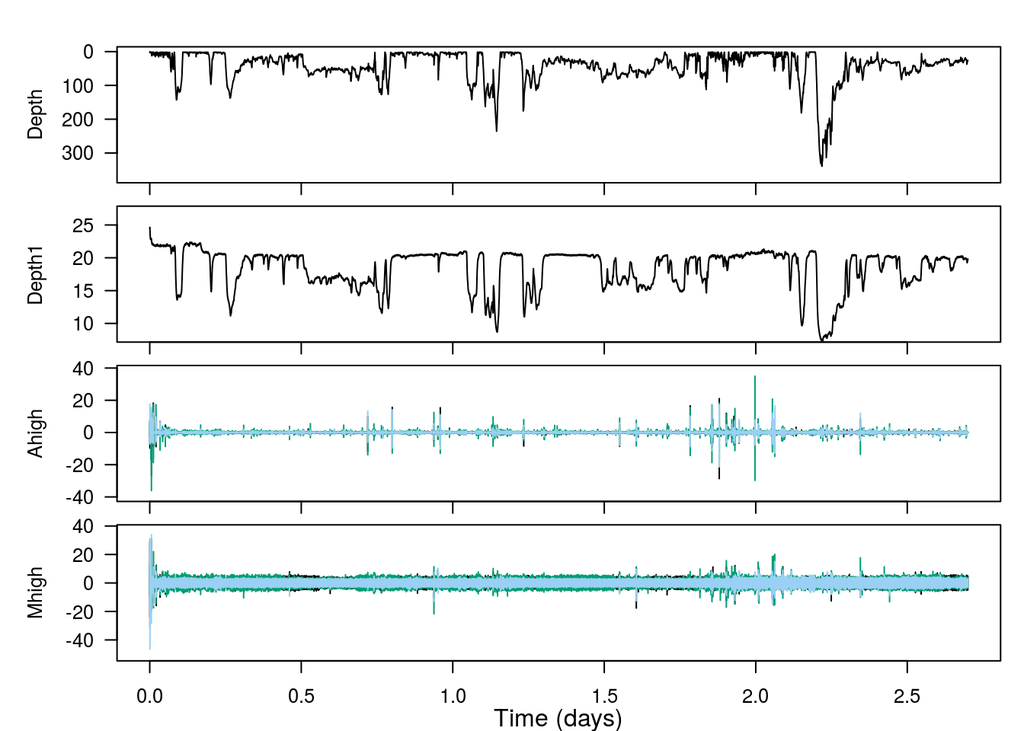

```r
fs <- A$sampling_rate
plott(X=list(Depth=P,Depth1= P1,Ahigh=Ahigh, Mhigh=Mhigh),
      fsx=fs, r=c(TRUE,FALSE,FALSE, FALSE))
```

```r
intvl1 <- c(0*24*60*60, 0.1*24*60*60)
intvl2 <- c(1.85*24*60*60, 2*24*60*60)
intvl3 <- c(2.6*24*60*60, 2.7*24*60*60)
```

### Plotting the segments where I though have more energetic movements.

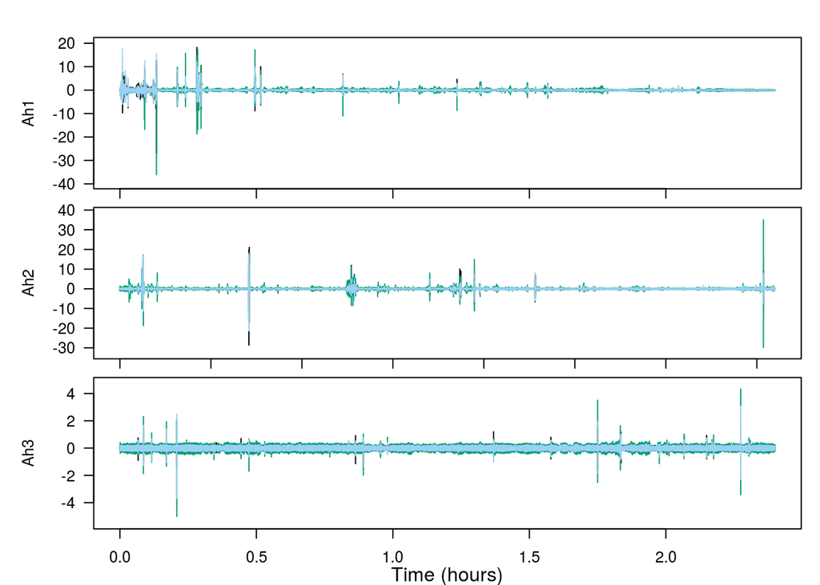

```r
Ah1 <- crop_to(Ahigh,sampling_rate=fs,
               tcues=intvl1)
Ah2 <- crop_to(Ahigh,sampling_rate=fs,
               tcues=intvl2)
Ah3 <- crop_to(Ahigh,sampling_rate=fs,
               tcues=intvl3)
plott(X = list(Ah1=Ah1, Ah2=Ah2, Ah3=Ah3),fsx=fs)
```

### The following lines from Mark Johnson Tagtools Practical 2 explains why Dynamic acceleration and Jerk are better metric to measure the prey capture.

“Sudden changes in acceleration are often associated with prey capture attempts although they can also arise in other activities such as social encounters, grooming, and in attacks by predators. Rapid changes mean high frequencies and so these will show up in the high pass filtered acceleration, Ahigh, that you made with the complementary filter. Because we don’t know what kind of movement is involved in a prey capture attempt, we don’t know which axis of acceleration will be most relevant. It is easier in this case, to just compute the magnitude of the three axes - that way a peak in any or all axes will show up. This gives what is sometimes called the dynamic acceleration. Another way to emphasize rapid changes in acceleration is by differentiating acceleration to produce the jerk. This is effectively high-pass filtering acceleration with a filter that has a roughly constant slope - the higher the frequency, the more it is emphasised.” - Mark Johnson Practical 2

# Dynamic Acceleration

Overall, Body Dynamic acceleration is a proxy of activity and energy expenditure (Lopez et al., 2021). From Papastamatiou et al. (2021) it was found that ODBA values were highest during the afternoon hours (16:00) and when near the surface. However, they decreased significantly when the depth was increased and early morning time. While calculating OBDA, the static acceleration (which comes from the earth’s gravitational pull) is removed and only the dynamic acceleration is used which is the measure of true movement of the animal.

# Jerk

Also, another important variable to understand is Jerk which is a proxy of fast movement of head and jaw. I am exploring the dataset to observe if there are high frequency acceleration signatures which indicates the feeding activity of shark.

# However, the question I have is that the tags were put in fins for shark and in this scenario can the jerk calculated from acceleration from sensors from fin a good measure of jerk?

```r
DA <- norm2(Ahigh)
J <- njerk(A)
```

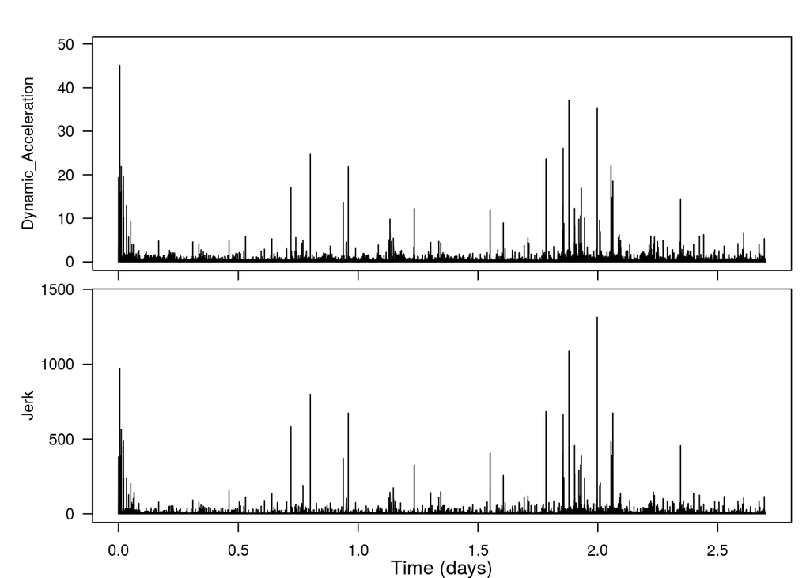

```r
plott(X=list(Dynamic_Acceleration=DA, Jerk=J),fsx=fs)
```

## Identifying the peaks that are larger than 150 m for Depth data. Here the X-axis represents the data points in their respective order.

```r
Dep_pks <- detect_peaks(P$data,sr= 20, thresh =150)
```

[output not shown]

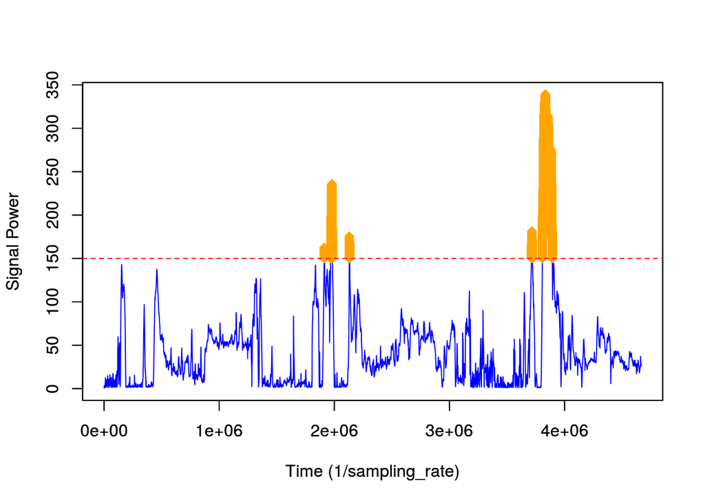

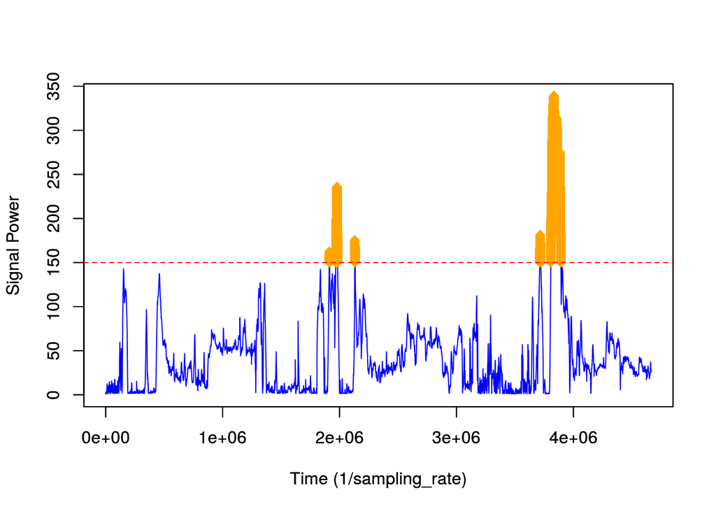

## Identifying the peaks that are larger than 300 m/sec cube for Jerk data.Here the X-axis represents the data points in their respective order.

```r
pks <- detect_peaks(J$data,sr= 20, thresh =300)
```

[output not shown]

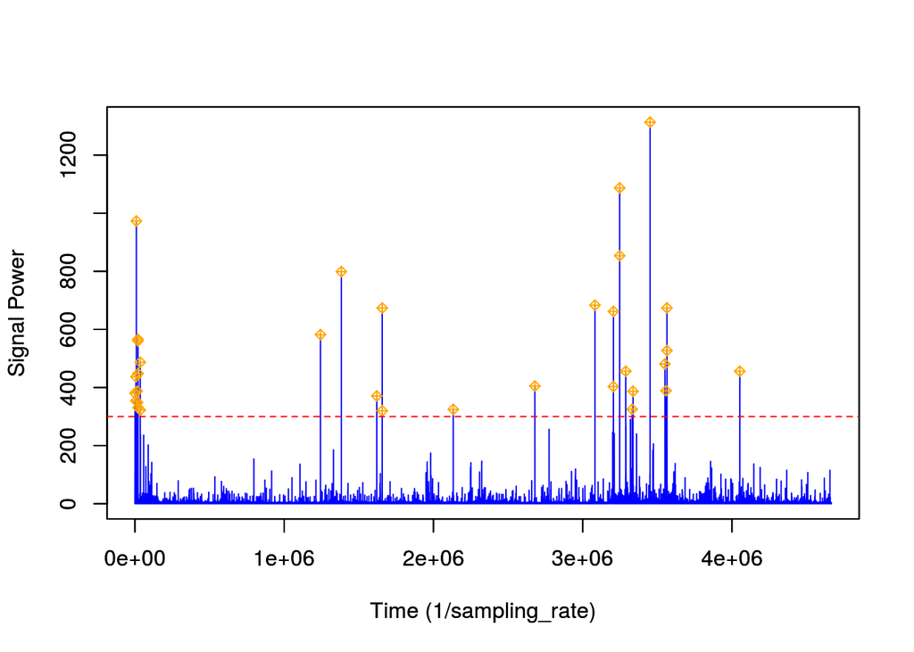

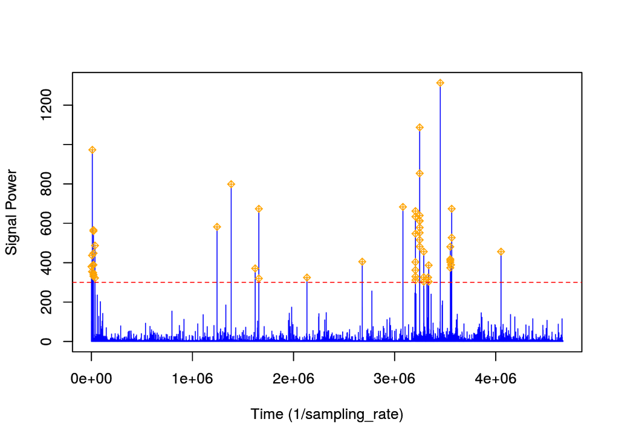

# Dead-reckoning ( Reconstruction of the track for White shark)

### The track3D function uses pitch, heading and depth data (if a starting point is provided) to reconstruct a track by fitting a state space model using a Kalman filter.

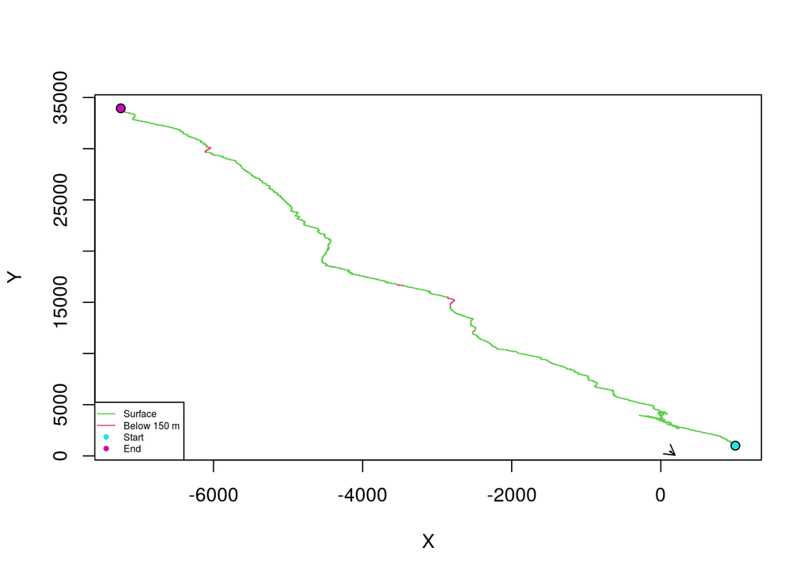

```r
trackts2=track3D(z=P$data,phi=p$p,psi=h$h,sf=MN$AccX$sampling_rate,r=0.001,q1p=0.02,q2p=0.08,q3p=1.6e-05,tagonx=1000,tagony=1000,x=NA,y=NA)

#how many obs
nobs=length(trackts2$fit.rx)
plot(trackts2$fit.rx,trackts2$fit.ry,xlab="X",ylab="Y",pch=".",col=ifelse(P$data<150,3,2))
points(trackts2$fit.rx[c(1,nobs)],trackts2$fit.ry[c(1,nobs)],pch=21,bg=5:6)
legend("bottomleft",cex=0.5,legend=c("Surface","Below 150 m","Start","End"),col=c(3,2,5,6),pt.bg=c(NA,NA,5,6),pch=c(NA,NA,21,21),lty=c(1,1,NA,NA))
polygon(x=c(120,140,140,120),y=c(400,400,450,450))
arrows(x0=130,y0=400,x1=190,y1=80,length=0.1)
```

one important thing that I learnt from Mark Johnson’s practical 3 is that tagonX (Easting of starting position (in meters, so requires projected data)) and tagonY (Northing of starting position (in meters, so requires projected data)) is required while generating p-tracks.In the example they are generated from the GPS latitude and longitude values. However, I have used 1000 m for both as set in tagtools R example because I don’t have GPS coordinates. According to the Mark Johnson tutorial (practical 3), there could be many inaccuracies with the dead-reckoned tracks. For the best results we need to make a qualitative and quantitative assessment of dead-reckoned track with the GPS track.

## Question: Is the dead-reckoned track that was reconstructed without starting position is a good representation of actual animal movement?